###### Recep Arda Kaya - 435060

# Clustering Algorithms Comparison on IBM HR Data

#### Compared Algorithms:

```
* K-Means Clustering
* Agglomerative Clustering
* DBSCAN Clustering
* Mean-Shift Clustering
* BIRCH Clustering
* Mini-batch k-means
```

## Objective

*Clustering aims to maximize intra-cluster similarity and minimize inter-cluster similarity.*

```
Each clustering problems requires own unique solutions. According to my observation, most of tutorials and guidebooks focus on K-means clustering and the data preparation process before. I want to introduce other clustering algorithms and  to inform when do we need other algorithms.
```

## Data

Due to more practical explanation, I am going to use [IBM HR Analytics Employee Attrition & Performance Dataset](https://www.kaggle.com/pavansubhasht/ibm-hr-analytics-attrition-dataset)

1) Review of the Data

1) a - Missing Value Check

1) b - Descriptive Statistics of Data

1) c - Univariate Variable Analysis: Numerical Data

1) d - Univariate Variable Analysis: Categorical Data

1) e - Basic Data Analysis: Categorical Data

1) f - Outlier Detection

1) g - Correlation Matrix: Categorical Data

1) h - Correlation Matrix: Numerical Data

2) Clustering Algorithms

2) a - Evaluation Metrics

2) b - K-Means Clustering

2) c - Agglomerative Clustering

2) d - DBSCAN Clustering

2) e - Mean-Shift Clustering

2) f - BIRCH Clustering

2) g - Mini batch K-Means Clustering

3) Results

4) References

## Review of the Data

```python
!pip install -U scikit-learn
```

[output not shown]

[output not shown]

```python
import sklearn
from sklearn import metrics

import pandas as pd
import numpy as np
import matplotlib
import matplotlib.pyplot as plt
import seaborn as sns
from tqdm import tqdm
from collections import Counter

import warnings
warnings.filterwarnings("ignore")

plt.style.use("seaborn-whitegrid")
```

```python
data = pd.read_csv(r'C:\Users\Arda\Downloads\WA_Fn-UseC_-HR-Employee-Attrition.csv')

data.head()
```

|  | Age | Attrition | BusinessTravel | DailyRate | Department | DistanceFromHome | Education | EducationField | EmployeeCount | EmployeeNumber | ... | RelationshipSatisfaction | StandardHours | StockOptionLevel | TotalWorkingYears | TrainingTimesLastYear | WorkLifeBalance | YearsAtCompany | YearsInCurrentRole | YearsSinceLastPromotion | YearsWithCurrManager |
| --- | --- | --- | --- | --- | --- | --- | --- | --- | --- | --- | --- | --- | --- | --- | --- | --- | --- | --- | --- | --- | --- |
| 0 | 41 | Yes | Travel_Rarely | 1102 | Sales | 1 | 2 | Life Sciences | 1 | 1 | ... | 1 | 80 | 0 | 8 | 0 | 1 | 6 | 4 | 0 | 5 |
| 1 | 49 | No | Travel_Frequently | 279 | Research & Development | 8 | 1 | Life Sciences | 1 | 2 | ... | 4 | 80 | 1 | 10 | 3 | 3 | 10 | 7 | 1 | 7 |
| 2 | 37 | Yes | Travel_Rarely | 1373 | Research & Development | 2 | 2 | Other | 1 | 4 | ... | 2 | 80 | 0 | 7 | 3 | 3 | 0 | 0 | 0 | 0 |
| 3 | 33 | No | Travel_Frequently | 1392 | Research & Development | 3 | 4 | Life Sciences | 1 | 5 | ... | 3 | 80 | 0 | 8 | 3 | 3 | 8 | 7 | 3 | 0 |
| 4 | 27 | No | Travel_Rarely | 591 | Research & Development | 2 | 1 | Medical | 1 | 7 | ... | 4 | 80 | 1 | 6 | 3 | 3 | 2 | 2 | 2 | 2 |

5 rows × 35 columns

```python
data.dtypes
```

```
Age                          int64
Attrition                   object
BusinessTravel              object
DailyRate                    int64
Department                  object
DistanceFromHome             int64
Education                    int64
EducationField              object
EmployeeCount                int64
EmployeeNumber               int64
EnvironmentSatisfaction      int64
Gender                      object
HourlyRate                   int64
JobInvolvement               int64
JobLevel                     int64
JobRole                     object
JobSatisfaction              int64
MaritalStatus               object
MonthlyIncome                int64
MonthlyRate                  int64
NumCompaniesWorked           int64
Over18                      object
OverTime                    object
PercentSalaryHike            int64
PerformanceRating            int64
RelationshipSatisfaction     int64
StandardHours                int64
StockOptionLevel             int64
TotalWorkingYears            int64
TrainingTimesLastYear        int64
WorkLifeBalance              int64
YearsAtCompany               int64
YearsInCurrentRole           int64
YearsSinceLastPromotion      int64
YearsWithCurrManager         int64
dtype: object
```

### Missing Value Check

```python
data.isnull().sum()
```

```
Age                         0
Attrition                   0
BusinessTravel              0
DailyRate                   0
Department                  0
DistanceFromHome            0
Education                   0
EducationField              0
EmployeeCount               0
EmployeeNumber              0
EnvironmentSatisfaction     0
Gender                      0
HourlyRate                  0
JobInvolvement              0
JobLevel                    0
JobRole                     0
JobSatisfaction             0
MaritalStatus               0
MonthlyIncome               0
MonthlyRate                 0
NumCompaniesWorked          0
Over18                      0
OverTime                    0
PercentSalaryHike           0
PerformanceRating           0
RelationshipSatisfaction    0
StandardHours               0
StockOptionLevel            0
TotalWorkingYears           0
TrainingTimesLastYear       0
WorkLifeBalance             0
YearsAtCompany              0
YearsInCurrentRole          0
YearsSinceLastPromotion     0
YearsWithCurrManager        0
dtype: int64
```

### Descriptive Statistics of Data

```python
data.describe()
```

|  | Age | DailyRate | DistanceFromHome | Education | EmployeeCount | EmployeeNumber | EnvironmentSatisfaction | HourlyRate | JobInvolvement | JobLevel | ... | RelationshipSatisfaction | StandardHours | StockOptionLevel | TotalWorkingYears | TrainingTimesLastYear | WorkLifeBalance | YearsAtCompany | YearsInCurrentRole | YearsSinceLastPromotion | YearsWithCurrManager |
| --- | --- | --- | --- | --- | --- | --- | --- | --- | --- | --- | --- | --- | --- | --- | --- | --- | --- | --- | --- | --- | --- |
| count | 1470.000000 | 1470.000000 | 1470.000000 | 1470.000000 | 1470.0 | 1470.000000 | 1470.000000 | 1470.000000 | 1470.000000 | 1470.000000 | ... | 1470.000000 | 1470.0 | 1470.000000 | 1470.000000 | 1470.000000 | 1470.000000 | 1470.000000 | 1470.000000 | 1470.000000 | 1470.000000 |
| mean | 36.923810 | 802.485714 | 9.192517 | 2.912925 | 1.0 | 1024.865306 | 2.721769 | 65.891156 | 2.729932 | 2.063946 | ... | 2.712245 | 80.0 | 0.793878 | 11.279592 | 2.799320 | 2.761224 | 7.008163 | 4.229252 | 2.187755 | 4.123129 |
| std | 9.135373 | 403.509100 | 8.106864 | 1.024165 | 0.0 | 602.024335 | 1.093082 | 20.329428 | 0.711561 | 1.106940 | ... | 1.081209 | 0.0 | 0.852077 | 7.780782 | 1.289271 | 0.706476 | 6.126525 | 3.623137 | 3.222430 | 3.568136 |
| min | 18.000000 | 102.000000 | 1.000000 | 1.000000 | 1.0 | 1.000000 | 1.000000 | 30.000000 | 1.000000 | 1.000000 | ... | 1.000000 | 80.0 | 0.000000 | 0.000000 | 0.000000 | 1.000000 | 0.000000 | 0.000000 | 0.000000 | 0.000000 |
| 25% | 30.000000 | 465.000000 | 2.000000 | 2.000000 | 1.0 | 491.250000 | 2.000000 | 48.000000 | 2.000000 | 1.000000 | ... | 2.000000 | 80.0 | 0.000000 | 6.000000 | 2.000000 | 2.000000 | 3.000000 | 2.000000 | 0.000000 | 2.000000 |
| 50% | 36.000000 | 802.000000 | 7.000000 | 3.000000 | 1.0 | 1020.500000 | 3.000000 | 66.000000 | 3.000000 | 2.000000 | ... | 3.000000 | 80.0 | 1.000000 | 10.000000 | 3.000000 | 3.000000 | 5.000000 | 3.000000 | 1.000000 | 3.000000 |
| 75% | 43.000000 | 1157.000000 | 14.000000 | 4.000000 | 1.0 | 1555.750000 | 4.000000 | 83.750000 | 3.000000 | 3.000000 | ... | 4.000000 | 80.0 | 1.000000 | 15.000000 | 3.000000 | 3.000000 | 9.000000 | 7.000000 | 3.000000 | 7.000000 |
| max | 60.000000 | 1499.000000 | 29.000000 | 5.000000 | 1.0 | 2068.000000 | 4.000000 | 100.000000 | 4.000000 | 5.000000 | ... | 4.000000 | 80.0 | 3.000000 | 40.000000 | 6.000000 | 4.000000 | 40.000000 | 18.000000 | 15.000000 | 17.000000 |

8 rows × 26 columns

### Univariate Variable Analysis: Numerical Data

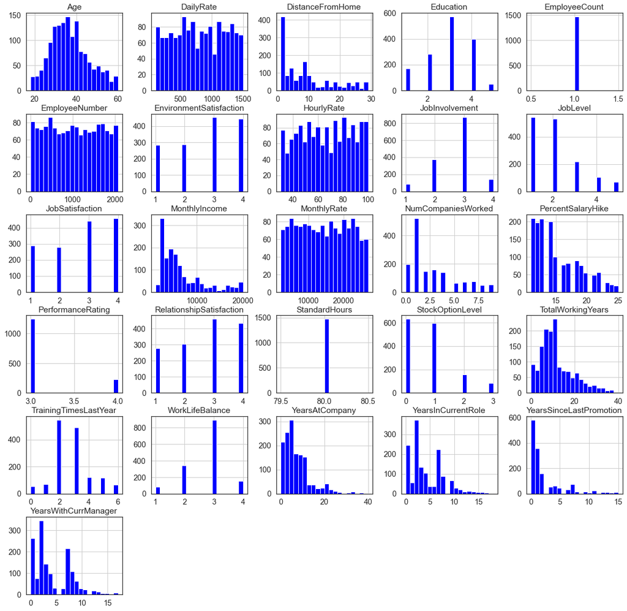

```python
sns.set(style='white',font_scale=1.3, rc={'figure.figsize':(20,20)})
ax=data.hist(bins=20,color='blue')
```

### Univariate Variable Analysis: Categorical Data

```python
def bar_plot(variable):

    var = data[variable]
    varValue = var.value_counts()

    plt.figure(figsize=(9,3))
    plt.bar(varValue.index,varValue)
    plt.xticks(varValue.index, varValue.index.values, rotation='vertical')
    plt.ylabel('Frequency')
    plt.title(variable)
    plt.show()
    print("{}: \n {}".format(variable,varValue))
```

#### Attrition

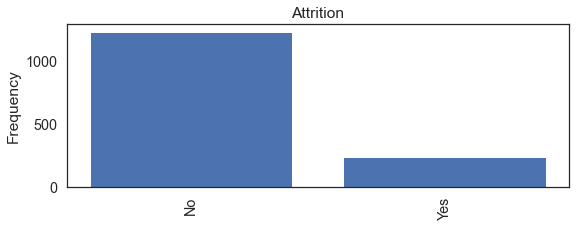

```
Attrition:
 No     1233
Yes     237
Name: Attrition, dtype: int64
```

```python
category_attrition = ['Attrition']

for c in category_attrition:
    bar_plot(c)
```

#### Business Travel

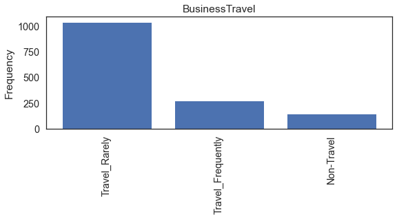

```
BusinessTravel:
 Travel_Rarely        1043
Travel_Frequently     277
Non-Travel            150
Name: BusinessTravel, dtype: int64
```

```python
from sklearn.preprocessing import OrdinalEncoder

ord_enc = OrdinalEncoder()
data['BusinessTravel_Encoded'] = ord_enc.fit_transform(data[['BusinessTravel']])

### TRAVEL RARELY = 2
### TRAVEL FREQUENTLY = 1
### NON-TRAVEL = 0

category_businesstravel = ['BusinessTravel']

for c in category_businesstravel:
    bar_plot(c)
```

#### Department

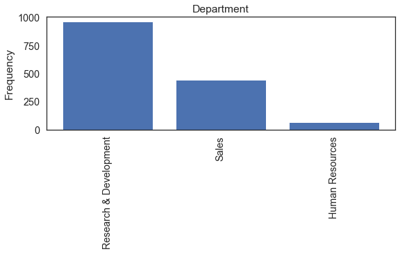

```
Department:
 Research & Development    961
Sales                     446
Human Resources            63
Name: Department, dtype: int64
```

```python
data['Department_Encoded'] = ord_enc.fit_transform(data[['Department']])

category_department = ['Department']

### SALES = 2
### RESEARCH = 1
### HR = 0

for c in category_department:
    bar_plot(c)
```

#### Education Field

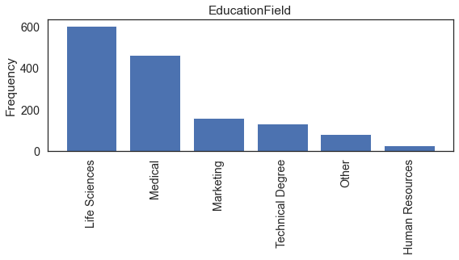

```
EducationField:
 Life Sciences       606
Medical             464
Marketing           159
Technical Degree    132
Other                82
Human Resources      27
Name: EducationField, dtype: int64
```

```python
data['EducationField_Encoded'] = ord_enc.fit_transform(data[['EducationField']])

### TECHNICAL DEGREE = 5
### OTHER = 4
### MEDICAL = 3
### MARKETING = 2
### LIFE SCIENCES = 1
### HR = 0

category_education = ['EducationField']

for c in category_education:
    bar_plot(c)
```

#### Gender

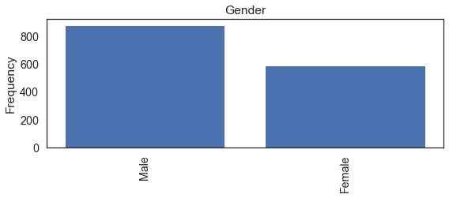

```
Gender:
 Male      882
Female    588
Name: Gender, dtype: int64
```

```python
data['Gender_Encoded'] = ord_enc.fit_transform(data[['Gender']])

### MALE = 1
### FEMALE = 0

category_gender = ['Gender']

for c in category_gender:
    bar_plot(c)
```

#### Job Role

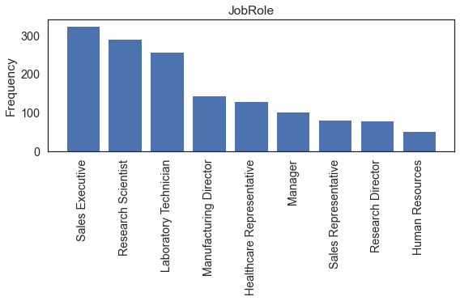

```
JobRole:
 Sales Executive              326
Research Scientist           292
Laboratory Technician        259
Manufacturing Director       145
Healthcare Representative    131
Manager                      102
Sales Representative          83
Research Director             80
Human Resources               52
Name: JobRole, dtype: int64
```

```python
data['JobRole_Encoded'] = ord_enc.fit_transform(data[['JobRole']])

### SALES REPRESENTATIVE = 8
### SALES EXECUTIVE = 7
### RESEARCH SCIENTIST = 6
### RESEARCH DIRECTOR = 5
### MANUFACTORING DIRECTOR = 4
### MANAGER = 3
### LABRATORY TECHNICAN = 2
### HR = 1
### HEALTHCARE REPRESANTATIVE = 0

category_jobrole = ['JobRole']

for c in category_jobrole:
    bar_plot(c)
```

#### Marital Status

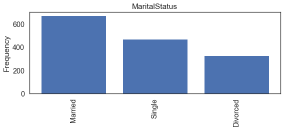

```
MaritalStatus:
 Married     673
Single      470
Divorced    327
Name: MaritalStatus, dtype: int64
```

```python
data['MaritalStatus_Encoded'] = ord_enc.fit_transform(data[['MaritalStatus']])


### SINGLE = 2
### MARRIED = 1
### DIVORCED = 0

category_maritalstatus = ['MaritalStatus']

for c in category_maritalstatus:
    bar_plot(c)
```

#### Over Time

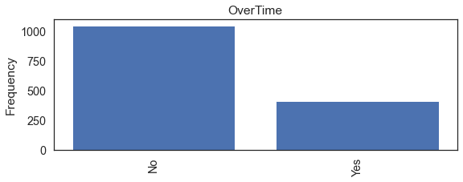

```
OverTime:
 No     1054
Yes     416
Name: OverTime, dtype: int64
```

```python
data['OverTime_Encoded'] = ord_enc.fit_transform(data[['OverTime']])

### YES = 1
### NO = 0

category_overtime = ['OverTime']

for c in category_overtime:
    bar_plot(c)
```

### Basic Data Analysis: Categorical Data

```
* Over Time - Attrition
* Job Role - Attrition
* Marital Status - Attrition
```

```python
data['Attrition_Binary'] = ord_enc.fit_transform(data[['Attrition']])

#data[['Attrition_Binary','Attrition']].head(10)
# 1 = YES
# 0 = NO

data[['OverTime','Attrition_Binary']].groupby(['OverTime'], as_index = False).mean().sort_values(by='Attrition_Binary',ascending=False)
```

|  | OverTime | Attrition_Binary |
| --- | --- | --- |
| 1 | Yes | 0.305288 |
| 0 | No | 0.104364 |

```python
data[['JobRole','Attrition_Binary']].groupby(['JobRole'], as_index = False).mean().sort_values(by='Attrition_Binary',ascending=False)
```

|  | JobRole | Attrition_Binary |
| --- | --- | --- |
| 8 | Sales Representative | 0.397590 |
| 2 | Laboratory Technician | 0.239382 |
| 1 | Human Resources | 0.230769 |
| 7 | Sales Executive | 0.174847 |
| 6 | Research Scientist | 0.160959 |
| 4 | Manufacturing Director | 0.068966 |
| 0 | Healthcare Representative | 0.068702 |
| 3 | Manager | 0.049020 |
| 5 | Research Director | 0.025000 |

```python
data[['MaritalStatus','Attrition_Binary']].groupby(['MaritalStatus'], as_index = False).mean().sort_values(by='Attrition_Binary',ascending=False)
```

|  | MaritalStatus | Attrition_Binary |
| --- | --- | --- |
| 2 | Single | 0.255319 |
| 1 | Married | 0.124814 |
| 0 | Divorced | 0.100917 |

### Outlier Detection

```python
def detect_outliers(df,features):

    outlier_indices = []

    for c in features:
        Q1 = np.percentile(df[c],25)

        Q3 = np.percentile(df[c],75)

        IQR = Q3 - Q1

        outlier_step = IQR * 1.5

        outlier_list_col = df[(df[c] < Q1 - outlier_step) | (df[c] > Q3 + outlier_step)].index

        outlier_indices.extend(outlier_list_col)

    outlier_indices = Counter(outlier_indices)
    multiple_outliers = list(i for i, v in outlier_indices.items() if v > 2)

    return multiple_outliers
```

```python
data.loc[detect_outliers(data,['Age','DailyRate','DistanceFromHome','EmployeeNumber','MonthlyIncome','MonthlyRate','NumCompaniesWorked','PercentSalaryHike','PerformanceRating','StockOptionLevel','TotalWorkingYears','TrainingTimesLastYear','YearsAtCompany','YearsInCurrentRole','YearsSinceLastPromotion','YearsWithCurrManager'])]
```

|  | Age | Attrition | BusinessTravel | DailyRate | Department | DistanceFromHome | Education | EducationField | EmployeeCount | EmployeeNumber | ... | YearsSinceLastPromotion | YearsWithCurrManager | BusinessTravel_Encoded | Department_Encoded | EducationField_Encoded | Gender_Encoded | JobRole_Encoded | MaritalStatus_Encoded | OverTime_Encoded | Attrition_Binary |
| --- | --- | --- | --- | --- | --- | --- | --- | --- | --- | --- | --- | --- | --- | --- | --- | --- | --- | --- | --- | --- | --- |
| 45 | 41 | Yes | Travel_Rarely | 1360 | Research & Development | 12 | 3 | Technical Degree | 1 | 58 | ... | 15 | 8 | 2.0 | 1.0 | 5.0 | 0.0 | 5.0 | 1.0 | 0.0 | 1.0 |
| 62 | 50 | No | Travel_Rarely | 989 | Research & Development | 7 | 2 | Medical | 1 | 80 | ... | 13 | 8 | 2.0 | 1.0 | 3.0 | 0.0 | 5.0 | 0.0 | 1.0 | 0.0 |
| 105 | 59 | No | Non-Travel | 1420 | Human Resources | 2 | 4 | Human Resources | 1 | 140 | ... | 2 | 2 | 0.0 | 0.0 | 0.0 | 0.0 | 3.0 | 1.0 | 0.0 | 0.0 |
| 123 | 51 | No | Travel_Rarely | 684 | Research & Development | 6 | 3 | Life Sciences | 1 | 162 | ... | 15 | 15 | 2.0 | 1.0 | 1.0 | 1.0 | 5.0 | 2.0 | 0.0 | 0.0 |
| 186 | 40 | No | Travel_Rarely | 989 | Research & Development | 4 | 1 | Medical | 1 | 253 | ... | 9 | 9 | 2.0 | 1.0 | 3.0 | 0.0 | 3.0 | 1.0 | 0.0 | 0.0 |
| ... | ... | ... | ... | ... | ... | ... | ... | ... | ... | ... | ... | ... | ... | ... | ... | ... | ... | ... | ... | ... | ... |
| 1086 | 50 | No | Travel_Frequently | 333 | Research & Development | 22 | 5 | Medical | 1 | 1539 | ... | 13 | 9 | 1.0 | 1.0 | 3.0 | 1.0 | 5.0 | 2.0 | 1.0 | 0.0 |
| 1138 | 50 | No | Travel_Frequently | 1234 | Research & Development | 20 | 5 | Medical | 1 | 1606 | ... | 12 | 13 | 1.0 | 1.0 | 3.0 | 1.0 | 0.0 | 1.0 | 1.0 | 0.0 |
| 1327 | 46 | No | Travel_Rarely | 1319 | Sales | 3 | 3 | Technical Degree | 1 | 1863 | ... | 2 | 8 | 2.0 | 2.0 | 5.0 | 0.0 | 7.0 | 0.0 | 0.0 | 0.0 |
| 926 | 43 | No | Travel_Rarely | 531 | Sales | 4 | 4 | Marketing | 1 | 1293 | ... | 15 | 17 | 2.0 | 2.0 | 2.0 | 0.0 | 7.0 | 2.0 | 0.0 | 0.0 |
| 1078 | 44 | No | Travel_Rarely | 136 | Research & Development | 28 | 3 | Life Sciences | 1 | 1523 | ... | 14 | 17 | 2.0 | 1.0 | 1.0 | 1.0 | 5.0 | 1.0 | 0.0 | 0.0 |

76 rows × 43 columns

```python
data = data.drop(detect_outliers(data,['Age','DailyRate','DistanceFromHome','EmployeeNumber','MonthlyIncome','MonthlyRate','NumCompaniesWorked','PercentSalaryHike','PerformanceRating','StockOptionLevel','TotalWorkingYears','TrainingTimesLastYear','YearsAtCompany','YearsInCurrentRole','YearsSinceLastPromotion','YearsWithCurrManager']),axis = 0).reset_index(drop = True)
```

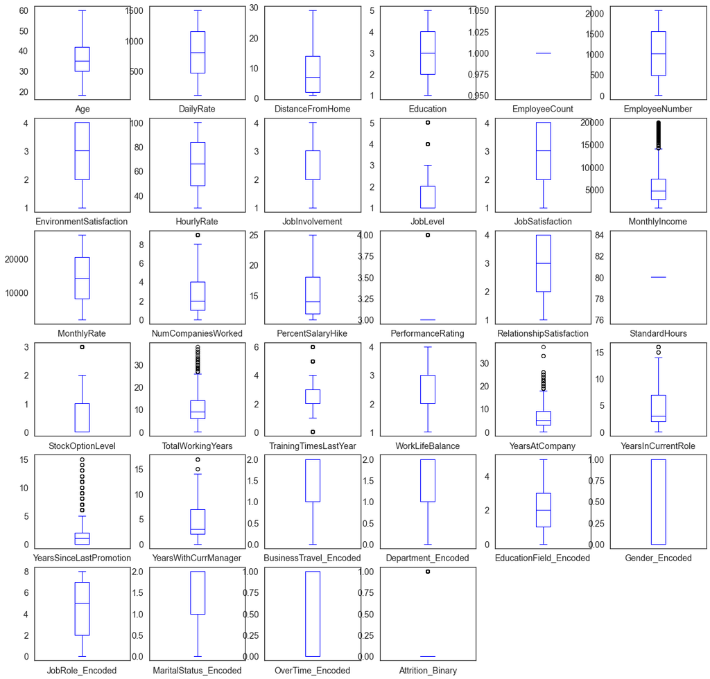

```python
data.plot( kind = 'box', subplots = True, layout = (6,6), sharex = False, sharey = False,color='blue')
plt.show()
```

### Correlation Matrix With Categorical Data

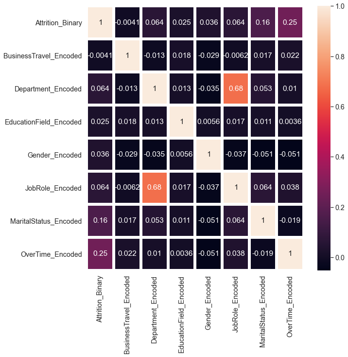

```python
encoded_data_features = data[['Attrition_Binary','BusinessTravel_Encoded','Department_Encoded','EducationField_Encoded','Gender_Encoded','JobRole_Encoded','MaritalStatus_Encoded','OverTime_Encoded']]

f,ax = plt.subplots(figsize=(10,10))
sns.heatmap(encoded_data_features.corr(),annot=True, linewidths=5, ax=ax)
plt.show()
```

##### According to correlation matrix above, there is meaningful relationship between attrition and over time.

### Correlation Matrix With Numerical Data

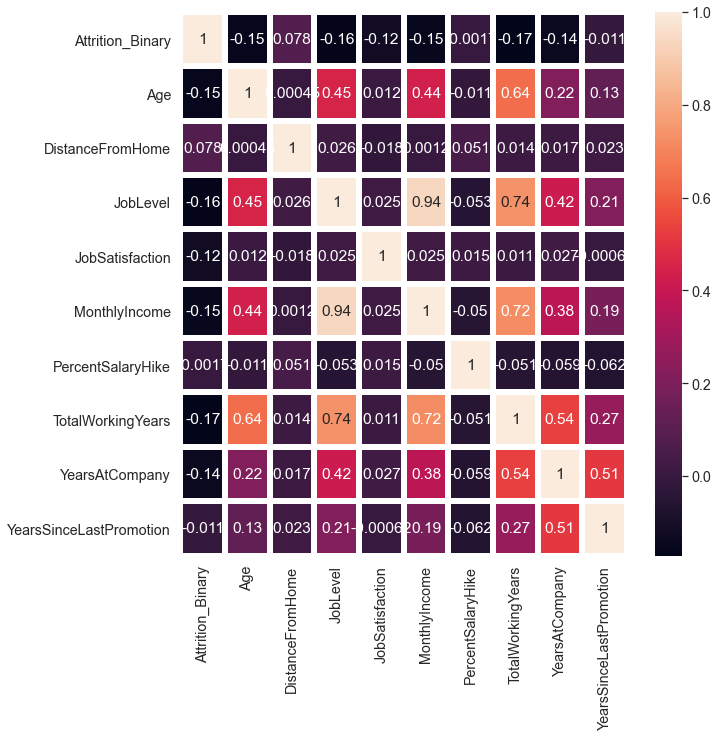

```python
numerical_data_features = data[['Attrition_Binary','Age','DistanceFromHome','JobLevel','JobSatisfaction','MonthlyIncome','PercentSalaryHike','TotalWorkingYears','YearsAtCompany','YearsSinceLastPromotion']]

f,ax = plt.subplots(figsize=(10,10))
sns.heatmap(numerical_data_features.corr(),annot=True, linewidths=5, ax=ax)
plt.show()
```

##### According to correlation matrix above, income, age and job level negatively correlated with attrition.

#### As a result of data analysis above, I decided to move on with " Over Time, Monthly Income, Total Working Years " features in my dataset.

## Clustering Algorithms

### 1) Centroid Based

```
    Cluster represented by central reference vector which may not be a part of the original data e.g k-means clustering

    * K-means Clustering
```

### 2) Hierarchical

```
    Connectivity based clustering based on the core idea that points are connected to points close by rather than
    further away. A cluster can be defined largely by the maximum distance needed to connect different parts of the
    cluster. Algorithms do not partition the dataset but instead construct a tree of points which are typically
    merged together.

    * Agglomerative Clustering
    * BIRCH Clustering
```

### 3) Distribution Based

```
    Built on statistical distribution models - objects of a cluster are the ones which belong likely to same
    distribution. Tend to be complex clustering models which might be prone to overfitting on data points

    * Gausssian mixture models
```

### 4) Density Based

```
    Create clusters from areas which have a higher density of data points. Objects in sparse areas, which seperate
    clusters, are considered noise and border points.

    * DBSCAN Clustering
    * Mean-shift Clustering
```

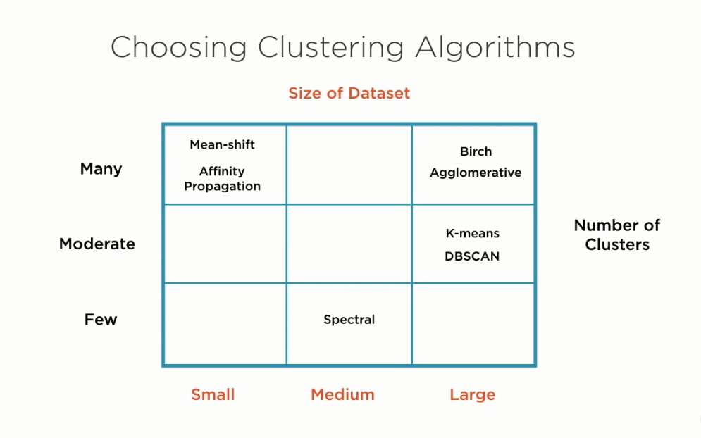

```python
from sklearn.cluster import KMeans
from sklearn.cluster import AgglomerativeClustering
from sklearn.cluster import DBSCAN
from sklearn.cluster import MeanShift
from sklearn.cluster import Birch
from sklearn.cluster import MiniBatchKMeans
```

```python
IBM_data = data[['Attrition_Binary','OverTime_Encoded','MonthlyIncome','TotalWorkingYears']]

IBM_data.head()
```

|  | Attrition_Binary | OverTime_Encoded | MonthlyIncome | TotalWorkingYears |
| --- | --- | --- | --- | --- |
| 0 | 1.0 | 1.0 | 5993 | 8 |
| 1 | 0.0 | 0.0 | 5130 | 10 |
| 2 | 1.0 | 1.0 | 2090 | 7 |
| 3 | 0.0 | 1.0 | 2909 | 8 |
| 4 | 0.0 | 0.0 | 3468 | 6 |

```python
IBM_data.shape
```

```
(1394, 4)
```

```python
IBM_data = IBM_data.sample(frac=1).reset_index(drop=True)
IBM_data.head()
IBM_data.info()
```

```
<class 'pandas.core.frame.DataFrame'>
RangeIndex: 1394 entries, 0 to 1393
Data columns (total 4 columns):
 #   Column             Non-Null Count  Dtype
---  ------             --------------  -----
 0   Attrition_Binary   1394 non-null   float64
 1   OverTime_Encoded   1394 non-null   float64
 2   MonthlyIncome      1394 non-null   int64
 3   TotalWorkingYears  1394 non-null   int64
dtypes: float64(2), int64(2)
memory usage: 43.7 KB
```

```python
IBM_data_features = IBM_data.drop('Attrition_Binary', axis=1)
IBM_data_features.head()
```

|  | OverTime_Encoded | MonthlyIncome | TotalWorkingYears |
| --- | --- | --- | --- |
| 0 | 0.0 | 2370 | 8 |
| 1 | 0.0 | 6151 | 19 |
| 2 | 0.0 | 8392 | 10 |
| 3 | 1.0 | 8189 | 12 |
| 4 | 1.0 | 13726 | 30 |

```python
IBM_data_attrition = IBM_data['Attrition_Binary']
IBM_data_attrition.sample(10)
```

```
102     0.0
82      0.0
635     0.0
1261    0.0
325     0.0
686     0.0
179     0.0
415     0.0
1144    1.0
1056    0.0
Name: Attrition_Binary, dtype: float64
```

### Evaluation Metrics

##### Homogeneity Score

```
Clustering satisfies homogeneity if all of its clusters contains only points which are members of a single class.
The actual label values do not matter i.e the fact that actual label 1 corresponds to cluster label 2 does
not affect this score
```

##### Completeness Score

```
Clustering satisfies completeness if all the points that are members of the same class belong to the same cluster
```

##### V Measure Score

```
Harmonic mean of homogeneity and completeness score - usually used to find the avarage of rates
```

##### Adjusted Rand Score

```
Similarity measure between clusters which is adjusted for chance i.e random labeling of data points
Close to 0: data was randomly labeled
Exact 1: actual and predicted clusters are identical
```

##### Adjusted Mutual Information Score

```
Information obtained about one random variable by observing another random variable adjusted to account for chance
Close to 0: data was randomly labeled
Exact 1: actual and predicted clusters are identical
```

##### Silhouette Score

```
Uses a distance metric to measure how similar a point is to its own cluster and how dissimilar the point is from
points in other clusters. Ranges between -1 and 1 and positive values closer to 1 indicate that the clustering
was good
```

```python
def BuildModel(clustering_model,data,labels):
    model=clustering_model(data)
    print('homo\tcompl\tv-means\tARI\tAMI\tsilhouette')
    print(50*'_')
    print('%.3f\t%.3f\t%.3f\t%.3f\t%.3f\t%.3f'
         %(metrics.homogeneity_score(labels, model.labels_),
           metrics.completeness_score(labels, model.labels_),
           metrics.v_measure_score(labels, model.labels_),
           metrics.adjusted_rand_score(labels, model.labels_),
           metrics.adjusted_mutual_info_score(labels, model.labels_),
           metrics.silhouette_score(data,model.labels_)))
```

#### K-Means Clustering

```
To process the learning data, the K-means algorithm in data mining starts with a first group of randomly
selected centroids, which are used as the beginning points for every cluster, and then performs iterative (repetitive)
calculations to optimize the positions of the centroids.It halts creating and optimizing clusters when either:
The centroids have stabilized — there is no change in their values because the clustering has been successful.
The defined number of iterations has been achieved.
```

#### Contrasting K-Means and Hierarchical Clustering

##### K-Means

```
* Need distance measure as well as way to aggregate points in a cluster
* Must represent data as vectors in N-dimensional hyperspace
* Data representation can be difficult for complex data types
* Variants can efficiently deal with very large datasets on disk
```

##### Hierarchical

```
* Only need distance measure; do not need way to combine points in cluster
* No need to express data as vectors in N-dimensional hyperspace
* Relatively simple to represent even complex documents
* Even with careful construction too computationaly expensive for large datasets on disk
```

```python
def k_means(data,n_clusters=2, max_iter=1000):
    model = KMeans(n_clusters=n_clusters, max_iter=max_iter).fit(data)

    return model
```

```python
BuildModel(k_means,IBM_data_features,IBM_data_attrition)
```

```
homo	compl	v-means	ARI	AMI	silhouette
__________________________________________________
0.006	0.006	0.006	-0.038	0.005	0.698
```

##### According to scores our k-means cluster perform did not well. Let's try other algorithms and hope an accuracy improvement

#### Agglomerative Clustering

```
Agglomerative Clustering is bottom-up hierarchical clustering. We will have tree representation of our data points and merge that our data points to another ones. Each step of agglomerative clustering merges the two clusters nearest to each other

What is the metric for nearness ?
    There are a few different approaches to solve this problem. Euclidian, L1, Cosine, Precomputed.

How is nearness measured ?
    Linkage criterion determines the distance to be minimized when merging clusters. There are four linkage criterion.
       * Single: Minimum of the distances between all points in two clusters.
       * Complete: Maximum of the distances between all points in two clusters
       * Average: Average distance between points in clusters.
       * Ward: Minimizes the variances of the data points in the two clusters.
```

```python
def agglomerative(data,n_clusters=2):
    model = AgglomerativeClustering(n_clusters = n_clusters).fit(data)

    return model
```

```
Bottom-up hierarchical clustering approach which recursively merges pairs of clusters, starting with single point
clusters.
Each merge tries to minimally increase the linkage distance between pairs of clusters.
The default linkage criterion is ward which minimizes the variances of clusters being merged.
```

```python
BuildModel(agglomerative,IBM_data_features,IBM_data_attrition)
```

```
homo	compl	v-means	ARI	AMI	silhouette
__________________________________________________
0.006	0.005	0.005	-0.032	0.005	0.675
```

##### According to scores our agglomerative cluster perform did not well. Let's try other algorithms and hope an accuracy improvement

#### DBSCAN Clustering

```
As I show before, when we have large datasets and moderate cluster count we might think to use k-means or DBSCAN
K-means for even cluster sizes and flat surfaces
DBSCAN for uneven cluster sizes and manifolds

DBSCAN = Density Based Spatial Clustering of Applications with Noise
    Density-based clustering groups together closely packed points
    Points with few near neighbours are marked as outliers
    Not as good as BIRCH at dealing with noise and outliers

There are two main parameters that we need to consider and specify
    eps = Minimum distance -points closer than this are neighbors-
       * If eps is too small most of the data will not be clustered
       * Unclustered points will be considered to be outliers
       * If eps is too large clustering will be too coarse
       * Most of the points will be in the same cluster

    min_samples = Minimum number of points to form a dense region
       * Generally this should be greater than number of dimensions in the data
       * Large values better for noisy data points, will form significant clusters
```

```python
def dbscan(data, eps=0.45, min_samples=2):
    model = DBSCAN(eps=eps, min_samples=min_samples).fit(data)

    return model
```

```
Groups points that are close to each other based on a distance measure and a minimum number of points
All points within maximum distance are considered neighbors
eps value will determine what we consider a dense region - smaller values are preferred
min_samples in the neighborhood for the point to be a core point
```

```python
BuildModel(dbscan,IBM_data_features,IBM_data_attrition)
```

```
homo	compl	v-means	ARI	AMI	silhouette
__________________________________________________
0.007	0.031	0.011	0.006	-0.001	-0.818
```

###### According to results, Overall, DBSCAN is not a good model to compare k-means or aggloremative clustering for this dataset.

#### Mean-shift Clustering

```
Starts with a set of points in space
One particular point define a neighborhood for each point and performs this actions for all data points
Each point will have its own neighborhood
For each point, calculate a function based on all points in the neighborhood. It is called kernel

Mean-shift has different kind of kernels
    * Flat kernal: Sum of all points in neighborhood. Each point gets the same weight
    * Gaussian kernel: Probability-weighted sum of points. Distribution is Gaussian
```

#### Contrasting K-Means and Mean-shift Clustering

##### K-means:

```
    * Need to specify number of clusters as hyperparameter
    * Can not handle some complex non-linear data
    * Less hyperparameter tuning needed
    * Computationally less intensive
    * O(N) in number of data points
    * Struggles with outliers
```

##### Mean-shift:

```
    * No need to specify number of clusters upfront as hyperparameter
    * Uses density function to handle even complex non-linear data like pixels
    * Hyperparameter tuning very important
    * Computationally very intensive
    * O(N2) in number of data points
    * Copes better with outliers
```

```python
def mean_shift(data, bandwidth=0.85):
    model = MeanShift(bandwidth=bandwidth).fit(data)

    return model
```

```
Algorithm tries to discover blobs in a smooth cluster of data points
Original seeds of the cluster are determined using a binning technique
```

```python
BuildModel(mean_shift,IBM_data_features,IBM_data_attrition)
```

```
homo	compl	v-means	ARI	AMI	silhouette
__________________________________________________
0.991	0.062	0.116	-0.000	-0.000	0.013
```

###### According to results, Mean-shift is not a good model to compare k-means or aggloremative clustering for this dataset.

#### BIRCH Clustering

```
As I show before, when we have large datasets and many cluster count we might think to use agglomerative or BIRCH
BIRCH detects and removes outliers
Also incrementally processes incoming data and updates clusters

BIRCH = Balanced Iterative Reducing and Clustering using Hierarchies
    * Very effective at handling noise and outliers
    * Very memory and time efficient
    * Entire dataset need not be loaded into memory
    * Incrementally clusters incoming data points
    * Updates clusters as new data arrives
    * Can deal with online streaming data !!
```

```python
def birch(data,n_clusters=2):
    model = Birch(n_clusters=n_clusters).fit(data)

    return model
```

```python
BuildModel(birch,IBM_data_features,IBM_data_attrition)
```

```
homo	compl	v-means	ARI	AMI	silhouette
__________________________________________________
0.006	0.005	0.005	-0.032	0.005	0.675
```

##### As a result, BIRCH did well according to silhouette score among last three algorithms. By far, our best scores came from k-means, agglomerative and BIRCH

#### Mini-batch K-means Clustering

```
When we have large datasets and moderate cluster count we might think to use Mini-batch K-means
Perform K-means on a randomly sampled subsets
Iteratively performed on batches called mini-batches
Far faster than full K-means
Performance usually only slightly worse
```

```python
def mini_batch_k_means(data, n_clusters=3, max_iter=1000):
    model = MiniBatchKMeans(n_clusters=n_clusters, max_iter=max_iter, batch_size=20).fit(data)

    return model
```

```python
BuildModel(mini_batch_k_means,IBM_data_features,IBM_data_attrition)
```

```
homo	compl	v-means	ARI	AMI	silhouette
__________________________________________________
0.029	0.013	0.018	-0.020	0.017	0.561
```

##### According to results, our mini batch k-means model performed slightly worse than original k-means algorithm

# Results

```
    In this project, my main objective was introduce different clustering techniques and compare their performances
 based on our dataset. Every clustering technique has designed for different type of data and clustering sizes.
 Because of this, every dataset, every different data cleaning techniques and every different hyper parameter
 tuning techniques are likely to change our results.

    To sum up;
        Small dataset and many number of clusters = Mean-shift, Affinity Propagation
        Medium dataset and few number of clusters = Spectral
        Large dataset and moderate number of clusters = K-means, DBSCAN
        Large dataset and many number of clusters = BIRCH, Aggloremative

    With our dataset, best efficient clustering techniques were K-means, Aggloremative and BIRCH. Because our dataset
is relatively big and our natural cluster sizes are a little more than avarage.

So why our other metrics than silhoutte were given us very bad scores?
    Probably I needed to much better data preparation solutions like PCA and I did statistical mistakes.

What did I learn?
    Clustering is much deeper than most of tutorial on the internet. For different scenarios we have to optimize
    our clustering algorithm and to pick right one.

Which one did I like most?
    I like BIRCH clustering most because its ability to handling online streaming data makes it a lot useful for
big data platforms and online machine learning services. Personally I like dynamic ML solutions a lot. I might think
to create a web project with BIRCH algorithm.
```

# References

```
* https://www.pluralsight.com/
* https://cloud.google.com/bigquery-ml/docs/kmeans-tutorial
* https://towardsdatascience.com/the-5-clustering-algorithms-data-scientists-need-to-know-a36d136ef68
```